# DATASCI 385 - Experimental Methods

Lecture 20 - Mediation Analysis

Danilo Freire

danilo.freire@emory.edu

Department of Data and Decision Sciences  
Emory University

# Hello again! 👋

# Brief recap 📚

## Last class: Interference

- We discussed two interesting papers (at least I hope you found them interesting! 😄)
- [**Paper 1: Munshi (2003)**](https://doi.org/10.1162/003355303321675455)
  - Goal: Identifying network effects in the labour market
  - Context: Mexican migrants in the US
  - Challenge: Endogeneity and selection bias
  - Method: Instrumental Variables (IV) using rainfall
- [**Paper 2: Miguel & Kremer (2004)**](https://onlinelibrary.wiley.com/doi/abs/10.1111/j.1468-0262.2004.00481.x)
  - Goal: Identifying treatment impacts with externalities
  - Context: Deworming programme in Kenyan schools
  - Challenge: Standard methods underestimate effects due to spillovers (SUTVA violation)
  - Method: Randomised phase-in design
- The focus of last class was on clever identification strategies when standard RCT assumptions are violated or RCTs are not feasible

# Today’s plan 📅

## Mediation: unpacking the black box

- What is mediation analysis? The search for causal mechanisms
- The classic regression-based approach (and why it’s often problematic)
- Thinking about mediation with potential outcomes
- The challenge of complex potential outcomes
- Can we experimentally manipulate mediators?
  - Factorial designs
  - Encouragement designs
  - The excludability problem
- A more pragmatic approach: Implicit mediation analysis
  - Adding/subtracting treatment components
- Examples: Conditional cash transfers, voter turnout mailers
- Strengths and limitations of different approaches
- Moving beyond simple ATEs to *how* effects happen

# What is mediation? 🤔

## The causal chain: Z → M → Y

- Experiments often tell us *that* a treatment ($Z$) affects an outcome ($Y$)
- Mediation analysis asks *how* or *why* this effect occurs
- It investigates the role of intermediate variables (mediators, $M$) that lie on the causal path between $Z$ and $Y$
- The core idea: $Z$ causes $M$, and $M$ causes $Y$
- Examples:
  - Limes ($Z$) → Vitamin C intake ($M$) → Reduced scurvy ($Y$)
  - Reserving council seats for women ($Z$) → Female incumbency/Changed attitudes ($M$) → Election of women later ($Y$) (Bhavnani 2009)
- Goal: Identify the pathways through which $Z$ influences $Y$

[figure not shown]

Read more: [Tröhler U (2003). James Lind and scurvy: 1747 to 1795.](https://www.jameslindlibrary.org/articles/james-lind-and-scurvy-1747-to-1795/)

## Why care about mechanisms?

- Scientific Understanding: Moves beyond “black box” descriptions to explanatory theories. How does the world work?
- Refining Theory: Tests specific theoretical propositions about causal processes
- Designing Better Interventions: If we know *why* something works, we might find more efficient or potent ways to achieve the same outcome (e.g., Vitamin C tablets instead of limes)
  - Mediators themselves can have mediators! Yes, really! Can you give an example?
- Generalisability: Understanding the mechanism helps predict if an effect will hold in different contexts where the mediator might operate differently
- Audiences and policymakers almost always ask about mechanisms!

## Types of mediation

### Simple mediation

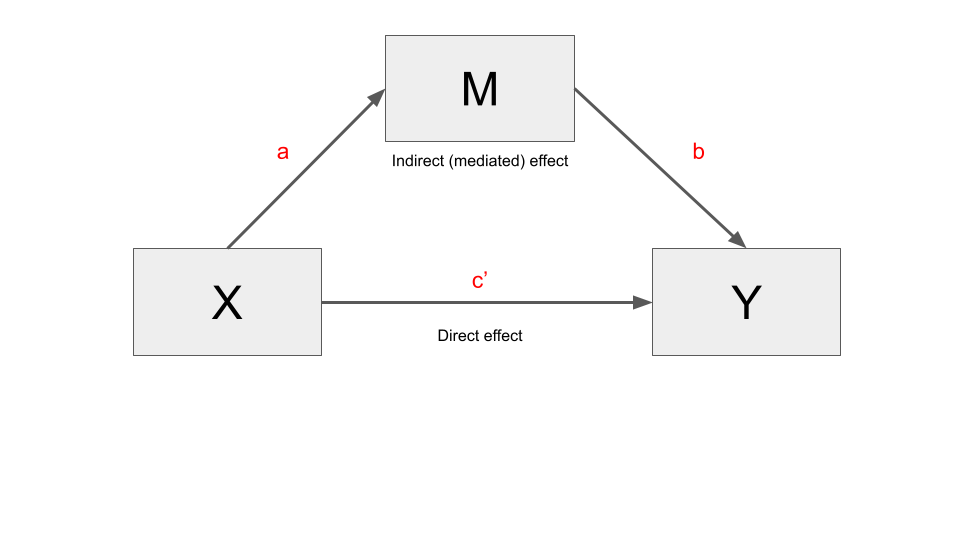

Source: [Righetti (2023)](https://nicolarighetti.github.io/mediation-moderation-and-conditional-process-analysis-with-r/mediation.html)

## Multiple Mediation

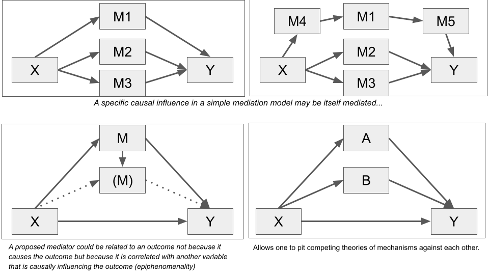

Source: [Righetti (2023)](https://nicolarighetti.github.io/mediation-moderation-and-conditional-process-analysis-with-r/mediation.html)

# The traditional approach: regression 📈

## The three-equation system

- A very common approach to estimate mediation is to use a three-equation system:
  1. Regress the mediator ($M$) on the treatment ($Z$): $M_i = \alpha_1 + a Z_i + e_{1i}$ Effect of Z on M: $\hat{a}$
  2. Regress the outcome ($Y$) on the treatment ($Z$): $Y_i = \alpha_2 + c Z_i + e_{2i}$ Total effect of Z on Y: $\hat{c}$
  3. Regress the outcome ($Y$) on both the treatment ($Z$) and the mediator ($M$): $Y_i = \alpha_3 + d Z_i + b M_i + e_{3i}$ Effect of M on Y: $\hat{b}$; Direct effect of Z on Y: $\hat{d}$
- $Z$ is randomly assigned (uncorrelated with errors, unbiased estimates of $Z$ in equations 01 and 02), but $M$ is *not* (equation 03). $M$ is an outcome of $Z$ (neither randomised nor pre-treatment). So equation 03 is an observational study (and it can be biased)!

## Decomposing effects (under strong assumptions)

- If we assume constant treatment effects (a, b, c, d are the same for everyone) and assume no unobserved confounding between $M$ and $Y$)…
- The total effect (c) can be decomposed:
  - Total Effect (c): How much $Y$ changes for a one-unit change in $Z$. Estimated from Eq. (2) (not shown in the figure)
  - Direct Effect (d): How much $Y$ changes for a one-unit change in $Z$, *holding $M$ constant*. Estimated from Eq. (3)
  - Indirect Effect (ab): How much of $Z$’s effect on $Y$ is transmitted *through* $M$. Calculated as $\hat{a}\hat{b}$ (or $\hat{c} - \hat{d}$)
- This decomposition ($c = d + ab$) is the cornerstone of traditional mediation analysis
- **BUT:** This relies heavily on the constant effects assumption.

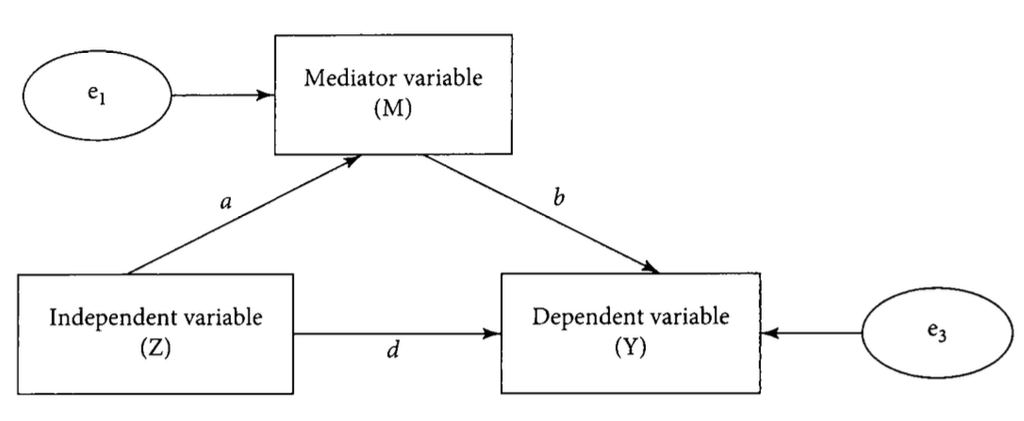

Source: Gerber & Green (2012, 323), *Field Experiments*, Figure 10.1

## The constant effects assumption

- Remember from our class on heterogeneous effects: causal effects often vary because people are different!
- If $a_i$ and $b_i$ vary across individuals, then the average indirect effect is $E[a_i b_i] = E[a_i] E[b_i] + Cov(a_i, b_i)$
- Simply multiplying the average effect of $Z$ on $M$ ($\hat{a} \approx E[a_i]$) by the average effect of $M$ on $Y$ ($\hat{b} \approx E[b_i]$) only gives the average indirect effect if $[Cov(a_i, b_i) = 0]$
- This covariance term is generally not zero and not identifiable
- So, the simple $c = d + ab$ decomposition breaks down with heterogeneous effects

## Why covariance matters: an example

- Let’s make this concrete with a job training programme example:
  - $Z$ = Job training programme
  - $M$ = New skills acquired
  - $Y$ = Employment outcome
- Two types of people in our population:
  - **Person A:** High-benefit type. Training massively boosts their skills ($a_i$ = large), and their new skills make them very employable ($b_i$ = large)
  - **Person B:** Low-benefit type. Training barely helps their skills ($a_i$ = small), and even with new skills, they are not very employable ($b_i$ = small)
- What researchers calculate: $\hat{a} \times \hat{b} = E[a_i] \times E[b_i]$
  - This is the product of averages - it treats everyone as if they are “average”
- The difference matters because of $Cov(a_i, b_i)$:
  - In our example, high-benefit people are high on BOTH dimensions
  - This means $Cov(a_i, b_i) > 0$ (positive correlation)
  - So $E[a_i \times b_i] = E[a_i] \times E[b_i] + \text{(number > 0)}$
  - The simple multiplication $\hat{a}\hat{b}$ underestimates the true effect!
  - The covariance term is generally not zero AND we cannot estimate it from data, so we can’t fix the simple formula

## The problem with equation (3): endogeneity of $M$

- Even if we ignore heterogeneous effects for a moment, Equation (3) is problematic: $Y_i = \alpha_3 + d Z_i + b M_i + e_{3i}$
- $Z$ is random, but $M$ is an outcome variable. It’s very likely correlated with the error term $e_{3i}$
- Why? Unobserved confounders might affect both M and Y
- **Example (Bhavnani):** Unmeasured local ‘egalitarianism’ ($e_{3i}$) might encourage women to run for office ($M$) *and* make voters more likely to elect women ($Y$), independently of the reservation policy ($Z$)
- Including $M$ in the regression is like including a post-treatment variable that is correlated with the error term!

## Regression approach summary

- Relies on strong, often implausible assumptions:
  - Constant treatment effects (for $c = d + ab$)
  - No unobserved confounding between $M$ and $Y$ (for unbiased $\hat{b}$ and $\hat{d}$)
- These assumptions are not guaranteed by random assignment of $Z$ alone
- Prone to bias because $M$ is not randomised
- Use with extreme caution, if at all, for causal mediation claims based solely on $Z$ randomisation

# A potential outcomes view

## Defining potential outcomes for mediation

- Let’s apply our familiar framework. For each individual $i$:
  - $Z_i$: Randomly assigned treatment (0 or 1)
  - $M_i(z)$: Potential value of the mediator if assigned to treatment $z$
  - $Y_i(z)$: Potential value of the outcome if assigned to treatment $z$
- Observed variables:
  - $M_i = M_i(Z_i)$
  - $Y_i = Y_i(Z_i)$
- Average Treatment Effect (Total Effect): $ATE = E[Y_i(1) - Y_i(0)]$
- Effect of $Z$ on $M$: $E[M_i(1) - M_i(0)]$
- These are estimable from a standard experiment randomising $Z$

## Expanding potential outcomes: $Y_i(m, z)$

- To formally define direct and indirect effects, we need a more complex notation (Imai, Keele, Yamamoto 2010; Robins & Greenland 1992):
- $Y_i(m, z)$: Potential outcome for individual $i$ if their mediator were set to value $m$ AND they were assigned treatment $z$
- This allows us to think about hypothetical scenarios:
  - What would $Y$ be if we gave the treatment ($z=1$) but somehow forced the mediator to the level it would have taken under control ($m=M_i(0)$)? This would be $Y_i(M_i(0), 1)$
  - These are called complex potential outcomes because they involve situations that can never happen in reality (more on that soon!)
- Linking back: $Y_i(1) = Y_i(M_i(1), 1)$ and $Y_i(0) = Y_i(M_i(0), 0)$

## Defining effects with $Y(m, z)$

- Using this notation, we can define effects more precisely:
- Total Effect (ATE): $E[Y_i(1) - Y_i(0)] = E[Y_i(M_i(1), 1) - Y_i(M_i(0), 0)]$
- Controlled Direct Effect (CDE): Effect of $Z$ on $Y$, holding $M$ fixed at some level $m$
  - $CDE(m) = E[Y_i(m, 1) - Y_i(m, 0)]$
- Natural Direct Effect (NDE): Effect of $Z$ on $Y$ if $M$ were held at the level it *would have taken* under control
  - $NDE = E[Y_i(M_i(0), 1) - Y_i(M_i(0), 0)]$
- Natural Indirect Effect (NIE): Effect of $M$ changing from $M_i(0)$ to $M_i(1)$, holding $Z$ fixed (usually at $Z=1$ for policy relevance)
  - $NIE = E[Y_i(M_i(1), 1) - Y_i(M_i(0), 1)]$
- Therefore, $ATE = NDE + NIE$

## The challenge: complex potential outcomes

- Look closely at the definitions of NDE and NIE:
  - NDE involves $Y_i(M_i(0), 1)$
  - NIE involves $Y_i(M_i(0), 1)$
- $Y_i(M_i(0), 1)$ represents the outcome under treatment ($Z=1$), but with the mediator at the level it would take under control ($M=M(0)$).
- Again, this can never happen in reality! If $Z_i=1$, we always observe $M_i(1)$, not $M_i(0)$
- These potential outcomes are fundamentally unobservable from any single experiment just randomising $Z$
- Now you see why mediation analysis is so tricky and why we don’t do it often! 😅

## Fundamental problem recap

- Estimating the theoretically precise Natural Direct Effect (NDE) and Natural Indirect Effect (NIE) requires knowing the values of complex potential outcomes like $Y_i(M_i(0), 1)$
- Since these are unobservable, we cannot estimate NDE and NIE without making strong assumptions
- Common assumptions include versions of “sequential ignorability” (Imai et al.), essentially assuming $M$ is “as-if randomised” conditional on $Z$ and pre-treatment covariates – very similar to the assumption needed for the regression approach to be unbiased
- Just randomising $Z$ is not sufficient to identify mediation pathways without these extra assumptions

# Can we address this? 🤔

## Ruling out mediators (a modest goal)

- What if we can show that $Z$ has *no effect* on $M$?
- If $M_i(1) = M_i(0)$ for *all* individuals $i$ (the sharp null hypothesis), then $M$ cannot possibly mediate the effect of Z
- In this case, the complex potential outcomes simplify: $Y_i(M_i(0), 1) = Y_i(M_i(1), 1) = Y_i(1)$. The NIE becomes zero
- **How to test this?**
  - Estimate the average effect: $E[M_i(1) - M_i(0)]$. If it’s not statistically different from zero, we have evidence against mediation through $M$
  - BUT: A zero average effect could hide heterogeneity (some increase, some decrease)
  - Test for heterogeneity: Check if $Var(M_i(1))$ differs from $Var(M_i(0))$. (As discussed in Lecture 18). If variances are similar and ATE is zero, it lends *support* to the sharp null
- Ruling out mediators is easier than quantifying mediation. Useful for eliminating hypotheses

## Example: Ruling out implicit bias as mediator

- Does diversity training ($Z$) reduce workplace discrimination ($Y$) through changing implicit bias ($M$)?
- Sharp null hypothesis: $M_i(1) = M_i(0)$ for all individuals $i$
  - That is, training has no effect on anyone’s implicit bias scores
- Empirical test: Randomly assign employees to training vs. control, measure implicit bias before/after
- Imagine we found the following:
  - Average effect: $E[M_i(1) - M_i(0)] = 0.02$ (not statistically different from zero)
  - Variance comparison: $Var(M_i(1)) = 15.3$ vs. $Var(M_i(0)) = 15.1$ (minimal difference)
- This suggests no evidence that training changes implicit bias on average, so $M$ is unlikely to mediate the effect of $Z$ on $Y$
- We don’t have unrefutable proof, but some evidence against this mediation pathway
- It is good practice to test multiple mediators this way to narrow down plausible mechanisms

## Manipulating the mediator directly?

### Factorial design to manipulate mediators

- We can also manipulate the mediator $M$ directly in an experiment, alongside $Z$
- Does a job training programme ($Z$) increase employment ($Y$) through skills acquisition ($M$)?

**2x2 Factorial Design to Manipulate $Z$ and $M$:**

| Group | Job Training ($Z$) | Skills Workshop ($M$) | Description |
| --- | --- | --- | --- |
| 1 | 0 | 0 | Control (no training, no workshop) |
| 2 | 0 | 1 | Skills workshop only |
| 3 | 1 | 0 | Job training only |
| 4 | 1 | 1 | Both training and workshop |

- What we can estimate:
- Controlled Direct Effect: Effect of training holding skills constant = (Group 3 - Group 1)
- Effect of skills holding training constant = (Group 4 - Group 3)
- Total training effect = (Group 3 - Group 1)
- Interaction effect = (Group 4 - Group 3) - (Group 2 - Group 1)
- We’re artificially setting skills levels through workshops
- But in reality, skills would develop naturally from job training
- The mechanism differs when we force $M$ vs. letting $M$ emerge naturally
- So we get Controlled Direct Effects, not Natural Direct Effects

## The encouragement design analogy

- Often, we can’t directly set $M$. Instead, we use an “encouragement” $Z$ to try and influence $M$
- Think back to non-compliance and Instrumental Variables (IV):
  - $Z$ = Assignment/Encouragement (e.g., offer tutoring)
  - $M$ = Treatment Received (e.g., actually attend tutoring)
  - $Y$ = Outcome (e.g., test score)
- We can use $Z$ as an instrument for $M$ to estimate the effect of $M$ on $Y$ for Compliers (CACE/LATE)
- This is sometimes framed as a mediation analysis: $Z$ affects $Y$ *through* its effect on $M$
- Formula: $CACE_{M \to Y} = \frac{ITT_{Y}}{ITT_{M}} = \frac{E[Y|Z=1] - E[Y|Z=0]}{E[M|Z=1] - E[M|Z=0]}$

## The excludability problem for IV/mediation

- For the IV estimate of the effect of $M$ on $Y$ to be valid, we need the exclusion restriction
- In the mediation context, this means $Z$ must affect $Y$ *only* through $M$. There can be no direct path from $Z$ to $Y$ ($d=0$)
- This is a very strong assumption! Often, the encouragement ($Z$) might affect the outcome ($Y$) through other channels besides the intended mediator ($M$).
- Example (Bhavnani): Seat reservations ($Z$) might affect future elections ($Y$) not just by creating incumbents ($M1$), but also by changing voter attitudes ($M2$) or mobilising different voters ($M3$)
- If $Z$ has a direct effect or affects multiple mediators, the simple IV approach doesn’t isolate the effect through one specific $M$
- Identifying effects through multiple mediators requires multiple encouragements (instruments) with different effects on the mediators – very complex!

# A different approach: implicit mediation 💡

## Scaling back ambitions: focus on treatment components

- Given the challenges of formally estimating direct/indirect effects or using IV with strong assumptions…
- An alternative: Implicit Mediation Analysis
- Instead of trying to measure $M$ and model the $Z$ → $M$ → $Y$ pathway explicitly…
- Focus on the treatment $Z$ itself. Many treatments are “bundles” of different components
- Design experiments that add or subtract specific components of the treatment bundle
- Compare the effects of these different treatment variations
- This implicitly tests the importance of the components (and the mediators they likely affect) without needing to measure $M$ or make strong assumptions about unobservables

## Example: Conditional cash transfers (CCTs)

- CCT programmes give cash to poor families if they meet certain conditions (e.g., school attendance, health check-ups)
- Potential mediators: Increased income (cash effect), Changed behaviour due to rules (conditionality effect)
- Implicit Mediation Design: (e.g., Baird et al. 2009)
  - Group 1: Control (no programme)
  - Group 2: Unconditional Cash Transfer (UCT - gets cash, no rules)
  - Group 3: Conditional Cash Transfer (CCT - gets cash + rules)
- Comparisons:
  - (Group 2 - Group 1): Effect of cash alone
  - (Group 3 - Group 1): Effect of cash + conditions
  - (Group 3 - Group 2): Effect of conditions (holding cash constant)
- This tells us about the importance of the *conditions* (likely mediator: behaviour change) vs. the *cash* (likely mediator: income) without directly measuring parental behaviour or income changes and modelling them

## Example: Voter turnout postcards (Gerber, Green, Larimer 2008)

- Famous experiment testing social pressure effects on voting
- Treatment “ingredients” gradually added:
  - Group 1: Control (no mail)
  - Group 2: “Civic Duty” mailer (basic encouragement)
  - Group 3: “Hawthorne” mailer (Civic Duty + told they are being studied)
  - Group 4: “Self” mailer (Hawthorne + shown own household’s past voting record)
  - Group 5: “Neighbours” mailer (Self + shown neighbours’ past voting records)
- Implicit mediators: Sense of duty, being watched, accountability for own record, comparison to neighbours

## Voter turnout results (Table 10.2)

**Illustrative Turnout Rates:**

| Group | Treatment Components | Turnout | Effect vs Control |
| --- | --- | --- | --- |
| 1. Control | None | 29.7% | – |
| 2. Civic Duty | Encouragement | 31.5% | +1.8% |
| 3. Hawthorne | Encouragement + Monitoring | 32.2% | +2.5% |
| 4. Self | Encouragement + Monitoring + Own Record | 34.5% | +4.8% |
| 5. Neighbours | Encouragement + Monitoring + All Records | 37.8% | +8.1% |

*(Based on Gerber, Green, and Larimer 2008)*

- Clear pattern: Adding social pressure components significantly increases turnout
- Comparing Group 5 vs 4 suggests disclosing neighbours’ records adds ~3.3% effect
- Comparing Group 4 vs 3 suggests disclosing own record adds ~2.3% effect
- Tells us *which ingredients matter* without modelling psychological states

## Interpreting implicit mediation

- This approach identifies which aspects of a complex intervention drive the effect
- It suggests the likely importance of different mediating *processes* (e.g., social comparison is powerful for turnout) without needing to directly measure or model the mediator variable (e.g., feelings of shame/pride)
- It’s inherently design-based and stays within the clean framework of comparing randomly assigned groups
- Very useful for programme evaluation and refinement!

## Strengths of implicit mediation

- Avoids bias inherent in regression-based mediation with non-randomised mediators
- Stays within the unbiased statistical framework of comparing randomised groups
- Lends itself to exploration and discovery of effective treatment variations
- Relies on weaker, design-based assumptions rather than statistical assumptions about unobservables
- Often more practical and feasible than trying to perfectly manipulate or measure mediators in field settings

# Conclusion

## Key takeaways on mediation

- Mediation analysis seeks to understand *how* a treatment $Z$ affects an outcome $Y$ through an intermediate variable $M$ (causal mechanisms)
- Traditional regression approaches are widespread but problematic:
  - Rely on constant effects assumption
  - Suffer from bias due to unobserved confounding between $M$ and $Y$
- The potential outcomes framework reveals fundamental challenges:
  - Estimating natural direct/indirect effects requires observing complex potential outcomes that are inherently unobservable
  - Randomising $Z$ alone is insufficient; strong assumptions are needed
- Experimentally manipulating $M$ helps estimate controlled effects but doesn’t fully solve the problem and may be artificial
- Using $Z$ as an instrument for $M$ requires the strong exclusion restriction (no direct $Z \to Y$ path), often violated
- Ruling out mediators (showing $Z$ doesn’t affect $M$) is a more modest but achievable goal
- Implicit mediation analysis is a pragmatic, design-based alternative:
  - Varies treatment components experimentally
  - Compares effects to infer which components (and likely mechanisms) matter
  - Avoids modelling $M$ directly, relies on fewer assumptions

## Final thoughts

- Be critical of causal mediation claims, especially those based solely on standard regression methods after randomising only $Z$
- Ask about the assumptions being made (constant effects? no confounding? exclusion restriction?)
- Favour design-based approaches where possible
- Implicit mediation offers a robust way to gain insights into mechanisms by comparing different versions of a treatment
- Understanding mechanisms is crucial, but requires careful thought about identification strategies!